# DeepTimeKB Examples

Date: 2020-12-16

### Introduction

This document generated by R Markdown shows how to install the *DeepTimeKB* package from GitHub and run examples. *DeepTimeKB* is an R package that queries knowledge and do knowledge inferences from the deep-time knowledge base.

Environment  
- R version: 4.0.3  
- RStudio: 1.2.5033  
- Platform: Mac OS 10.15.3

Authors: Chao Ma (chao@uidaho.edu), Xiaogang Ma (max@uidaho.edu)

### Install and load necessary packages

Install *devtools* package

```r
install.packages("devtools", repos = "https://cloud.r-project.org")
```

Install *DeepTimeKB* package from GitHub

```r
devtools::install_github("xgmachina/DeeptTimeKB_RLib", force = T)
```

Load *DeepTimeKB*

```r
library(DeepTimeKB)
```

### Examples

#### 1. List available scheme in deep-time knowledge base

For a geoscientist, an intuitive first question using the *DeepTimeKB* package is to know what are the available vocabularies of iGTS and rGTS in the knowledge base. This information can be obtained by running function *gts.listRegion*. It returns both the identifier and the literal name of all vocabulary schemes in the knowledge base.

```r
gts.listRegion()
```

```
##                                                            schURI
## 1    <http://resource.geosciml.org/vocabulary/timescale/tswe2019>
## 2    <http://resource.geosciml.org/vocabulary/timescale/tste2019>
## 3    <http://resource.geosciml.org/vocabulary/timescale/tssi2019>
## 4    <http://resource.geosciml.org/vocabulary/timescale/tssc2019>
## 5    <http://resource.geosciml.org/vocabulary/timescale/tsru2019>
## 6    <http://resource.geosciml.org/vocabulary/timescale/tsnz2019>
## 7    <http://resource.geosciml.org/vocabulary/timescale/tsnc2019>
## 8    <http://resource.geosciml.org/vocabulary/timescale/tsna2019>
## 9    <http://resource.geosciml.org/vocabulary/timescale/tska2019>
## 10   <http://resource.geosciml.org/vocabulary/timescale/tsjp2019>
## 11 <http://resource.geosciml.org/vocabulary/timescale/tsibmo2019>
## 12   <http://resource.geosciml.org/vocabulary/timescale/tsca2019>
## 13   <http://resource.geosciml.org/vocabulary/timescale/tsbr2019>
## 14   <http://resource.geosciml.org/vocabulary/timescale/tsbo2019>
```

[output cut: 59 more lines]

#### 2. List all geologic time concepts in the level of Era from the international geologic time scale

After choosing a vocabulary scheme, the function *gts.list* can be used to list all geologic time concepts of a certain level in that vocabulary. Two parameters need to be specified in this function. The parameter “region” controls the scheme, while “level” determines the concept level (i.e. Eon, Era, Period, Epoch, or Age).

```r
gts.list(region = "international", level = "Era")
```

```
##              [,1]
## geoConcept   "Eoarchean Era"
## geoConcept.1 "Paleoarchean Era"
## geoConcept.2 "Mesoarchean Era"
## geoConcept.3 "Neoarchean Era"
## geoConcept.4 "Paleoproterozoic Era"
## geoConcept.5 "Mesoproterozoic Era"
## geoConcept.6 "Neoproterozoic Era"
## geoConcept.7 "Paleozoic Era"
## geoConcept.8 "Mesozoic Era"
## geoConcept.9 "Cenozoic Era"
```

#### 3. Extract properties of Mata Epoch from the regional geologic time scale of New Zealand

The properties associated with a certain geologic concept can be extracted by running the function *gts*.

```r
gts(geoConcept = "Mata")
```

```
##                           geoConcept
## 1  <http://deeptimekb.org/tsnz#Mata>
## 2  <http://deeptimekb.org/tsnz#Mata>
## 3  <http://deeptimekb.org/tsnz#Mata>
## 4  <http://deeptimekb.org/tsnz#Mata>
## 5  <http://deeptimekb.org/tsnz#Mata>
## 6  <http://deeptimekb.org/tsnz#Mata>
## 7  <http://deeptimekb.org/tsnz#Mata>
## 8  <http://deeptimekb.org/tsnz#Mata>
## 9  <http://deeptimekb.org/tsnz#Mata>
## 10 <http://deeptimekb.org/tsnz#Mata>
## 11 <http://deeptimekb.org/tsnz#Mata>
##                                                   property
## 1        <http://www.w3.org/1999/02/22-rdf-syntax-ns#type>
## 2        <http://www.w3.org/1999/02/22-rdf-syntax-ns#type>
```

[output cut: 21 more lines]

#### 4. Find the levels of geologic time concpets of “Mata” and “Jurassic”

In some cases the level of a specific geologic time concept is needed for further analysis. The function *gts.level* can be used, in which the input is the literal name of a geologic time concept, and the output is the vocabulary scheme and level of the concept.

```r
gts.level(geoConcept = "Mata")
```

```
##   schemeID geoConcpet level
## 1 tsnz2019       Mata Epoch
```

```r
gts.level(geoConcept = "Jurassic")
```

```
##      schemeID geoConcpet  level
## 1  isc2020-03   Jurassic Period
## 2  isc2020-01   Jurassic Period
## 3  isc2019-05   Jurassic Period
## 4  isc2018-08   Jurassic Period
## 5  isc2018-07   Jurassic Period
## 6  isc2017-02   Jurassic Period
## 7  isc2016-10   Jurassic Period
## 8  isc2016-04   Jurassic Period
## 9  isc2015-01   Jurassic Period
## 10 isc2014-10   Jurassic Period
## 11 isc2014-02   Jurassic Period
## 12 isc2013-01   Jurassic Period
## 13 isc2012-08   Jurassic Period
## 14 isc2010-09   Jurassic Period
## 15 isc2009-08   Jurassic Period
## 16 isc2008-08   Jurassic Period
## 17 isc2006-04   Jurassic Period
## 18 isc2005-12   Jurassic Period
## 19 isc2004-04   Jurassic Period
```

#### 5. Query all geologic time concepts that contain the 50 Ma time point

The function *gts.point* answers the question about which geologic time concepts contain a specific time point in Earth history.

```r
gts.point(time = 50)
```

```
##      schemeID       geoConcept begTimeNum endTimeNum duration
## 1  isc2004-04     Ypresian Age      55.80      48.60     7.20
## 2  isc2004-04     Eocene Epoch      55.80      33.90    21.90
## 3  isc2004-04 Paleogene Period      65.50      23.03    42.47
## 4  isc2004-04     Cenozoic Era      65.50       0.00    65.50
## 5  isc2004-04  Phanerozoic Eon     542.00       0.00   542.00
## 6  isc2005-12     Ypresian Age      55.80      48.60     7.20
## 7  isc2005-12     Eocene Epoch      55.80      33.90    21.90
## 8  isc2005-12 Paleogene Period      65.50      23.03    42.47
## 9  isc2005-12     Cenozoic Era      65.50       0.00    65.50
## 10 isc2005-12  Phanerozoic Eon     542.00       0.00   542.00
## 11 isc2006-04     Ypresian Age      55.80      48.60     7.20
## 12 isc2006-04     Eocene Epoch      55.80      33.90    21.90
## 13 isc2006-04 Paleogene Period      65.50      23.03    42.47
## 14 isc2006-04     Cenozoic Era      65.50       0.00    65.50
```

[output cut: 85 more lines]

#### 6. Retrieve attributes of “Wordian Age”

The function *gts.range* can extract start and end time, vocabulary scheme, and duration of a specific geologic time concept. In this function a parameter “iscVersion” can be set for querying the geologic time concept from a specific version of ISC in the iGTS. The parameter “region” can be set for retrieving the concept from a specific vocabulary scheme in the rGTS.

```r
gts.range(geoConcept = "Wordian") # Not specifying the region of the concept
```

```
##      schemeID  geoConcpet begTimeValue endTimeValue duration
## 1    tsna2019 Wordian Age        268.8       265.14     3.66
## 2  isc2020-03 Wordian Age        268.8       265.10     3.70
## 3  isc2020-01 Wordian Age        268.8       265.10     3.70
## 4  isc2019-05 Wordian Age        268.8       265.10     3.70
## 5  isc2018-08 Wordian Age        268.8       265.10     3.70
## 6  isc2018-07 Wordian Age        268.8       265.10     3.70
## 7  isc2017-02 Wordian Age        268.8       265.10     3.70
## 8  isc2016-10 Wordian Age        268.8       265.10     3.70
## 9  isc2016-04 Wordian Age        268.8       265.10     3.70
## 10 isc2015-01 Wordian Age        268.8       265.10     3.70
## 11 isc2014-10 Wordian Age        268.8       265.10     3.70
## 12 isc2014-02 Wordian Age        268.8       265.10     3.70
## 13 isc2013-01 Wordian Age        268.8       265.10     3.70
## 14 isc2012-08 Wordian Age        268.8       265.10     3.70
## 15 isc2010-09 Wordian Age        268.0       265.80     2.20
## 16 isc2009-08 Wordian Age        268.0       265.80     2.20
## 17 isc2008-08 Wordian Age        268.0       265.80     2.20
## 18 isc2006-04 Wordian Age        268.0       265.80     2.20
## 19 isc2005-12 Wordian Age        268.0       265.80     2.20
## 20 isc2004-04 Wordian Age        268.0       265.80     2.20
```

```r
gts.range(geoConcept = "Wordian", region = "North America") # Specifying the region of the concept
```

```
##   schemeID  geoConcpet begTimeValue endTimeValue duration
## 1 tsna2019 Wordian Age        268.8       265.14     3.66
```

#### 7. Query geologic time concepts between 10 and 15 Ma

The function *gts.within* is for querying geologic time concepts inside a specific duration of time of which the start and end time are set by two parameters “geotime1” and “geotime2”.

```r
gts.within(geotime1 = 10, geotime2 = 15)
```

```
##      schemeID       geoConcept
## 1  isc2004-04 Serravallian Age
## 2  isc2005-12 Serravallian Age
## 3  isc2006-04 Serravallian Age
## 4  isc2008-08 Serravallian Age
## 5  isc2009-08 Serravallian Age
## 6  isc2010-09 Serravallian Age
## 7  isc2012-08 Serravallian Age
## 8  isc2013-01 Serravallian Age
## 9  isc2014-02 Serravallian Age
## 10 isc2014-10 Serravallian Age
## 11 isc2015-01 Serravallian Age
## 12 isc2016-04 Serravallian Age
## 13 isc2016-10 Serravallian Age
## 14 isc2017-02 Serravallian Age
## 15 isc2018-07 Serravallian Age
## 16 isc2018-08 Serravallian Age
## 17 isc2019-05 Serravallian Age
## 18 isc2020-01 Serravallian Age
## 19 isc2020-03 Serravallian Age
## 20   tsau2019 Bairnsdalian Age
## 21   tsjp2019      Kaburan Age
## 22   tsnz2019      Waiauan Age
```

#### 8. Find broader and narrower concepts of “Mata Epoch”

The function *gts.hierarchy* can return the broader and narrower concepts of an input concept, thus to show the hierarchical structure in the GTS.

```r
gts.hierarchy(geoConcept = "Mata")
```

```
##   schemeID    broaderConcept inputConcept narrowerConcept
## 1 tsnz2019 Cretaceous Period   Mata Epoch   Haumurian Age
## 2 tsnz2019 Cretaceous Period   Mata Epoch   Piripauan Age
```

#### 9. Query GSSP data from the 2018-07 International Stratigraphic Chart in the knowledge graph

The function *gts.gssp* is created to query the GSSP information from the knowledge graph. All GSSP information can be obtained by running *gts.gssp()*, and the parameter “iscVersion” can be set to query the information only from a certain version of ISC in the iGTS. The returned information includes vocabulary scheme, GSSP name, longitude, and latitude.

```r
gts.gssp(iscVersion = "2018-07")
```

```
##      schemeID                                          GSSP  longitude
## 1  isc2018-07           Stratotype Point Base of Priabonian   11.91802
## 2  isc2018-07              Stratotype Point Base of Pridoli    14.3249
## 3  isc2018-07           Stratotype Point Base of Quaternary    14.2035
## 4  isc2018-07            Stratotype Point Base of Santonian     2.1968
## 5  isc2018-07            Stratotype Point Base of Selandian    -2.2594
## 6  isc2018-07         Stratotype Point Base of Serravallian    14.3361
## 7  isc2018-07             Stratotype Point Base of Silurian      -3.27
## 8  isc2018-07           Stratotype Point Base of Sinemurian    -3.2364
## 9  isc2018-07            Stratotype Point Base of Telychian      -3.79
## 10 isc2018-07            Stratotype Point Base of Thanetian    -2.2594
## 11 isc2018-07            Stratotype Point Base of Tortonian    13.5694
## 12 isc2018-07             Stratotype Point Base of Turonian  -104.7275
## 13 isc2018-07     Stratotype Point Base of Upper Cretaceous     5.5119
## 14 isc2018-07       Stratotype Point Base of Upper Devonian     3.0868
```

[output cut: 135 more lines]

#### 10. Plot the GSSP data from the 2018-07 International Stratigraphic Chart in the knowledge graph on a world map

The function *gssp.map* can visualize the GSSP information by plotting all GSSPs on a world map, in which the parameter “iscVersion” can be used to set the version of ISC in the iGTS.

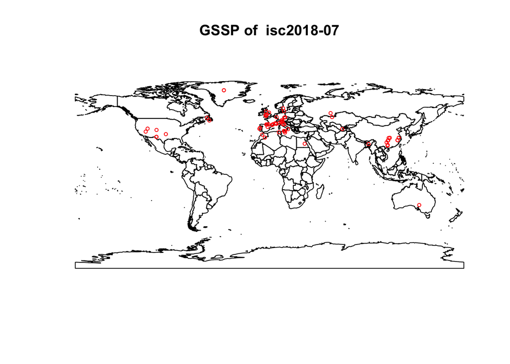

```r
gssp.map(iscVersion = "2018-07")
```

#### 11. Knowledge inference of temporal topology between two geologic time concepts

In the *DeeptimeKB* package, the function *gts.topo* is created to implement the temporal topology. The input of this function is two geologic time concepts, and each is specified by two parameters: 1) concept name and 2) region in the rGTS or version of ISC in the iGTS.

```r
gts.topo(geoConcept1 = "Jurassic", region1 = "international", iscVersion1 = "2018-07", geoConcept2 = "Mesozoic", region2 = "international", iscVersion2 = "2018-07") # two concepts from the same scheme
```

```
## #### RESULT ####
## Jurassic  time:intervalStartedBy  Mesozoic
```

```
## [1] "time:intervalStartedBy"
```

```r
gts.topo(geoConcept1 = "Jurassic", region1 = "international", iscVersion1 = "2018-07", geoConcept2 = "Mata", region2 = "New Zealand") # two concepts from two different schemes
```

```
## #### RESULT ####
## Jurassic  time:intervalAfter  Mata
```

```
## [1] "time:intervalAfter"
```